# Working with categorical features in ML

~

2020-01-20

This weekend I decided to dive into the [Categorical Feature Encoding Challenge II](https://www.kaggle.com/c/cat-in-the-dat-ii) that Kaggle is hosting so I could learn some things about using categorical features in machine learning models.

For this challenge, the dataset contained **only categorical features** and also different **kinds** of categorical features: Binary, nominal, and ordinal. On top of that, some of the features had low cardinality, while other features had high cardinality.

In the context of machine learning, “cardinality” refers to the number of possible values that a feature can assume. For example, the variable “US State” is one that has 50 possible values. Dealing with high cardinality turned out to be one of the most interesting parts of the challenge. It’s a problem that I haven’t encountered much before, certainly not to this extent.

There was a wide range of cardinality. The binary features, of course, could only assume one of two values (0 or 1). One of the ordinal features was uppercase letters of the alphabet, so it had 26 possible values. A feature that really took the cake had more than 1000 possible alpha-numeric strings like `de4c57ee2`. And not only that, but some of the values were unique – only appearing once in the training set.

Improper encoding of high-cardinality features can lead to poor model performance, and memory issues when trying to fit the model because encoding can result in extremely large matrices of values. For example, a common strategy for encoding categorical variables is “one-hot” or “dummy” encoding, where a new column is created for N (or N-1) of the possible values, and those columns are given a value of 1 or 0 depending on whether the feature had that value. Below is an example of dummy encoding for 4 hair colors:

Original variable:

| hair_color |
| --- |
| red |
| black |
| brown |
| blonde |

Dummy / one-hot encoded variable with N columns:

| hair_color_red | hair_color_black | hair_color_brown | hair_color_blonde |
| --- | --- | --- | --- |
| 1 | 0 | 0 | 0 |
| 0 | 1 | 0 | 0 |
| 0 | 0 | 1 | 0 |
| 0 | 0 | 0 | 1 |

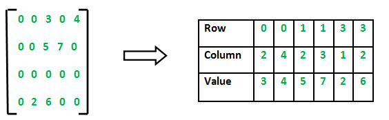

‘sparse matrix’